# A permutation test for the Mother/Daughter heights data

### Biostatistics in Practice HPC workshop, February 2014

### This lab was adapted for $\href{http://statsteachr.org}{statsTeachR}$ by Emily Ramos from a lab written by Nicholas G Reich and are released under a $\href{http://creativecommons.org/licenses/by-sa/3.0/deed.en_US}{Creative Commons Attribution-ShareAlike 3.0 Unported License}$.

This file documents an analysis to evaluate the significance of the association between mother and daughter heights. We will analyze the “heights” dataset from the `R` package `alr3`.

```r
require(alr3)
data(heights)
```

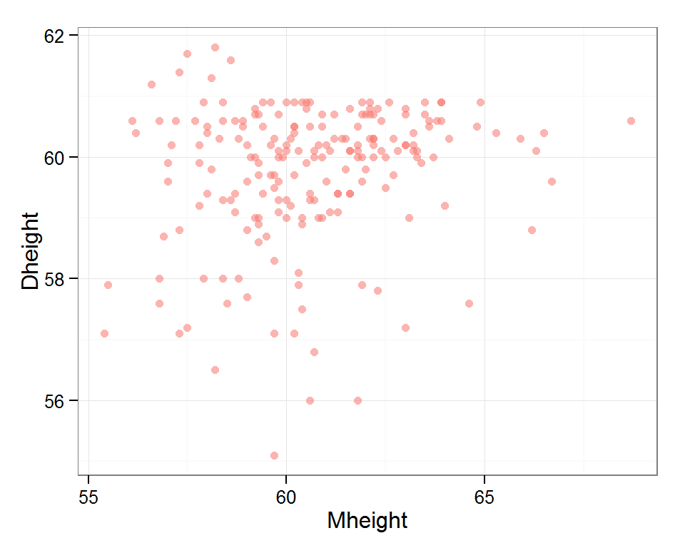

```r
heights <- heights[sample(200),]
require(ggplot2)
theme_set(theme_bw()) ## sets default white background theme for ggplot
qplot(Mheight, Dheight, data=heights, col="red", alpha=.5) + theme(legend.position="none")
```

#### Running the permutation test

We are interested in fitting the model $Dheight_i \sim \beta_0 + \beta_1 \cdot Mheight_i + \epsilon_i$ and in drawing inference about the $\beta_1$ parameter. Specifically, we are going to run a permutation test to evaluate evidence for or against the null hypothesis $H_0: \beta_1=0$.

The following code runs the permutation test. [Sidenote: This code chunk is typically the kind of code chunk that you would want to cache in an RMarkdown file. However, if we were to cache it, then the subsample of the heights dataset would change every time the file was compiled but the permutation test would not be re-run each time. Cached chunks are only re-run when the code within that chunk is changed.]

```r
nSim <- 1000 ## number of permutations

## fit initial model and create storage file
realDataModel <- lm(Dheight ~ Mheight, data=heights)
realData_beta1 <- coef(realDataModel)[2]

## create storage matrix
mat <- matrix(NA, nrow=nSim, ncol=2)
colnames(mat) <- c("b0", "b1")

## run permutation loop, storing each time
for(i in 1:nSim) {
        permDhts <- sample(heights$Dheight, replace=FALSE)
        mdl <- lm(permDhts ~ heights$Mheight)
        mat[i,] <- coef(mdl)
}
```

Now that we have our distribution of $\beta_1$ under the null hypothesis, we can compare the estimate of $\beta_1$ from the real data analysis. Notice that we calculate a two-sided p-value by calculating how many $|\hat\beta_1^{(i)}| > \beta_1$.

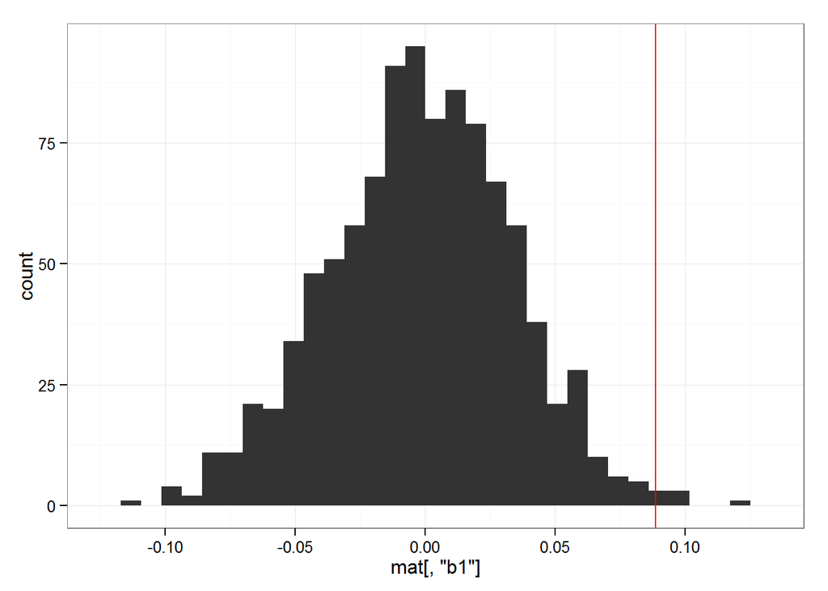

```r
qplot(mat[,"b1"]) + geom_vline(xintercept = realData_beta1, color="red")
```

```r
pval <- sum(abs(mat[,"b1"]) > realData_beta1)/nrow(mat)
```

The resulting p-value is 0.012.